# Name: Jay Rakeshbhai Patel

# Project Name : Module 7 Report - Crime

# 1. Objective of the Proposed Research

1. This Research Papers aims to analyze data about Crime activites and Crime types of the year of 1975-2015.
2. The main objective of this research to analyze and represents the data of the frequent crime type and there same frequency to the FBI for cop to the crime ratio.(FBI is ours Stakeholders)
3. In this project ours main work to create data of series crime and normal crime data provide this report of ours stakeholders.
4. To find the total numbers of perticular crime and their years and cities.
5. We calculated the rate of crime in each category and for all crime, totle residents in the jurisdiction, based on the FBI’s estimated population for that year. on bais on this i sort the data.

# 2. Data Exploration

In this step we import the data file and some usefull libraries for upcoming steps and then after do some exploration of the find numbers of the rows, columns, sort the data, data types and data mean, max , min values.

```python
import numpy as np
import pandas as pd
import matplotlib.pyplot as plt
import seaborn as sns
```

```python
X = pd.read_csv("report.csv")
```

```python
X
```

|  | report_year | agency_code | agency_jurisdiction | population | violent_crimes | homicides | rapes | assaults | robberies | months_reported | crimes_percapita | homicides_percapita | rapes_percapita | assaults_percapita | robberies_percapita |
| --- | --- | --- | --- | --- | --- | --- | --- | --- | --- | --- | --- | --- | --- | --- | --- |
| 0 | 1975 | NM00101 | Albuquerque, NM | 286238.0 | 2383.0 | 30.0 | 181.0 | 1353.0 | 819.0 | 12.0 | 832.52 | 10.48 | 63.23 | 472.68 | 286.13 |
| 1 | 1975 | TX22001 | Arlington, TX | 112478.0 | 278.0 | 5.0 | 28.0 | 132.0 | 113.0 | 12.0 | 247.16 | 4.45 | 24.89 | 117.36 | 100.46 |
| 2 | 1975 | GAAPD00 | Atlanta, GA | 490584.0 | 8033.0 | 185.0 | 443.0 | 3518.0 | 3887.0 | 12.0 | 1637.44 | 37.71 | 90.30 | 717.10 | 792.32 |
| 3 | 1975 | CO00101 | Aurora, CO | 116656.0 | 611.0 | 7.0 | 44.0 | 389.0 | 171.0 | 12.0 | 523.76 | 6.00 | 37.72 | 333.46 | 146.58 |
| 4 | 1975 | TX22701 | Austin, TX | 300400.0 | 1215.0 | 33.0 | 190.0 | 463.0 | 529.0 | 12.0 | 404.46 | 10.99 | 63.25 | 154.13 | 176.10 |
| ... | ... | ... | ... | ... | ... | ... | ... | ... | ... | ... | ... | ... | ... | ... | ... |
| 2824 | 2015 | OK07205 | Tulsa, OK | 401520.0 | 3628.0 | 55.0 | 365.0 | 2354.0 | 854.0 | NaN | 903.57 | 13.70 | 90.90 | 586.27 | 212.69 |
| 2825 | 2015 | VA12800 | Virginia Beach, VA | 452797.0 | 626.0 | 19.0 | 103.0 | 234.0 | 270.0 | NaN | 138.25 | 4.20 | 22.75 | 51.68 | 59.63 |
| 2826 | 2015 | DCMPD00 | Washington, DC | 672228.0 | 8084.0 | 162.0 | 494.0 | 4024.0 | 3404.0 | NaN | 1202.57 | 24.10 | 73.49 | 598.61 | 506.38 |
| 2827 | 2015 | KS08703 | Wichita, KS | 389824.0 | 3839.0 | 27.0 | 349.0 | 2730.0 | 733.0 | NaN | 984.80 | 6.93 | 89.53 | 700.32 | 188.03 |
| 2828 | 2015 | NaN | United States | NaN | 1197704.0 | 15696.0 | NaN | NaN | NaN | NaN | 372.60 | 4.90 | NaN | NaN | NaN |

2829 rows × 15 columns

```python
X.head()
```

|  | report_year | agency_code | agency_jurisdiction | population | violent_crimes | homicides | rapes | assaults | robberies | months_reported | crimes_percapita | homicides_percapita | rapes_percapita | assaults_percapita | robberies_percapita |
| --- | --- | --- | --- | --- | --- | --- | --- | --- | --- | --- | --- | --- | --- | --- | --- |
| 0 | 1975 | NM00101 | Albuquerque, NM | 286238.0 | 2383.0 | 30.0 | 181.0 | 1353.0 | 819.0 | 12.0 | 832.52 | 10.48 | 63.23 | 472.68 | 286.13 |
| 1 | 1975 | TX22001 | Arlington, TX | 112478.0 | 278.0 | 5.0 | 28.0 | 132.0 | 113.0 | 12.0 | 247.16 | 4.45 | 24.89 | 117.36 | 100.46 |
| 2 | 1975 | GAAPD00 | Atlanta, GA | 490584.0 | 8033.0 | 185.0 | 443.0 | 3518.0 | 3887.0 | 12.0 | 1637.44 | 37.71 | 90.30 | 717.10 | 792.32 |
| 3 | 1975 | CO00101 | Aurora, CO | 116656.0 | 611.0 | 7.0 | 44.0 | 389.0 | 171.0 | 12.0 | 523.76 | 6.00 | 37.72 | 333.46 | 146.58 |
| 4 | 1975 | TX22701 | Austin, TX | 300400.0 | 1215.0 | 33.0 | 190.0 | 463.0 | 529.0 | 12.0 | 404.46 | 10.99 | 63.25 | 154.13 | 176.10 |

2.(1) in this first we sort the data using head command and shows first 10 rows.

```python
X.head(10)
```

|  | report_year | agency_code | agency_jurisdiction | population | violent_crimes | homicides | rapes | assaults | robberies | months_reported | crimes_percapita | homicides_percapita | rapes_percapita | assaults_percapita | robberies_percapita |
| --- | --- | --- | --- | --- | --- | --- | --- | --- | --- | --- | --- | --- | --- | --- | --- |
| 0 | 1975 | NM00101 | Albuquerque, NM | 286238.0 | 2383.0 | 30.0 | 181.0 | 1353.0 | 819.0 | 12.0 | 832.52 | 10.48 | 63.23 | 472.68 | 286.13 |
| 1 | 1975 | TX22001 | Arlington, TX | 112478.0 | 278.0 | 5.0 | 28.0 | 132.0 | 113.0 | 12.0 | 247.16 | 4.45 | 24.89 | 117.36 | 100.46 |
| 2 | 1975 | GAAPD00 | Atlanta, GA | 490584.0 | 8033.0 | 185.0 | 443.0 | 3518.0 | 3887.0 | 12.0 | 1637.44 | 37.71 | 90.30 | 717.10 | 792.32 |
| 3 | 1975 | CO00101 | Aurora, CO | 116656.0 | 611.0 | 7.0 | 44.0 | 389.0 | 171.0 | 12.0 | 523.76 | 6.00 | 37.72 | 333.46 | 146.58 |
| 4 | 1975 | TX22701 | Austin, TX | 300400.0 | 1215.0 | 33.0 | 190.0 | 463.0 | 529.0 | 12.0 | 404.46 | 10.99 | 63.25 | 154.13 | 176.10 |
| 5 | 1975 | MD00301 | Baltimore County, MD | 642154.0 | 1259.0 | 25.0 | 137.0 | 347.0 | 750.0 | 12.0 | 196.06 | 3.89 | 21.33 | 54.04 | 116.79 |
| 6 | 1975 | MDBPD00 | Baltimore, MD | 864100.0 | 16086.0 | 259.0 | 463.0 | 6309.0 | 9055.0 | 12.0 | 1861.59 | 29.97 | 53.58 | 730.12 | 1047.91 |
| 7 | 1975 | MA01301 | Boston, MA | 616120.0 | 11386.0 | 119.0 | 453.0 | 3036.0 | 7778.0 | 12.0 | 1848.02 | 19.31 | 73.52 | 492.76 | 1262.42 |
| 8 | 1975 | NY01401 | Buffalo, NY | 422276.0 | 3350.0 | 63.0 | 192.0 | 755.0 | 2340.0 | 12.0 | 793.32 | 14.92 | 45.47 | 178.79 | 554.14 |
| 9 | 1975 | NC06001 | Charlotte, NC | 262103.0 | 1937.0 | 68.0 | 71.0 | 976.0 | 822.0 | 12.0 | 739.02 | 25.94 | 27.09 | 372.37 | 313.62 |

List of all columns

report_year - complain registered year

agency_code - code of agency who filed the complain

agency_jurisdiction - location of jurisdiction

population - population in that jurisdiction area

violent_crime - total number of different types crime

homicides - number of homicides

rapes - number of rapes

assaulats - number of assaulats

robberies - number of robberies

```python
X.columns
```

```
Index(['report_year', 'agency_code', 'agency_jurisdiction', 'population',
       'violent_crimes', 'homicides', 'rapes', 'assaults', 'robberies',
       'months_reported', 'crimes_percapita', 'homicides_percapita',
       'rapes_percapita', 'assaults_percapita', 'robberies_percapita'],
      dtype='object')
```

2.(2)  
to find the numbers of the columns and numbers of the rows using the shape command.

```python
X.shape
```

```
(2829, 15)
```

```python
X.shape[0]
```

```
2829
```

```python
X.shape[1]
```

```
15
```

2.3 in this step find ther percentage of the data using the quantile fuction.

```python
X.quantile([.1,.25,.50,.75],axis=0).T
```

|  | 0.10 | 0.25 | 0.50 | 0.75 |
| --- | --- | --- | --- | --- |
| report_year | 1979.000 | 1985.0000 | 1995.00 | 2005.0000 |
| population | 289452.200 | 377931.0000 | 536614.50 | 816855.7500 |
| violent_crimes | 1706.300 | 3014.7500 | 5135.50 | 9058.5000 |
| homicides | 17.000 | 32.0000 | 64.00 | 131.0000 |
| rapes | 103.000 | 176.2500 | 291.00 | 465.0000 |
| assaults | 816.400 | 1467.0000 | 2597.00 | 4556.0000 |
| robberies | 570.600 | 1032.0000 | 1940.00 | 3609.7500 |
| months_reported | 12.000 | 12.0000 | 12.00 | 12.0000 |
| crimes_percapita | 384.008 | 625.0825 | 949.68 | 1409.5075 |
| homicides_percapita | 3.464 | 6.9550 | 11.98 | 20.2300 |
| rapes_percapita | 22.839 | 35.7750 | 55.90 | 77.7975 |
| assaults_percapita | 163.502 | 319.0900 | 487.48 | 728.2400 |
| robberies_percapita | 115.763 | 210.2425 | 374.40 | 612.0050 |

2.4 In this step i found the whole data information , data type, data desripetions.

```python
X.info()
```

```
<class 'pandas.core.frame.DataFrame'>
RangeIndex: 2829 entries, 0 to 2828
Data columns (total 15 columns):
 #   Column               Non-Null Count  Dtype
---  ------               --------------  -----
 0   report_year          2829 non-null   int64
 1   agency_code          2788 non-null   object
 2   agency_jurisdiction  2829 non-null   object
 3   population           2760 non-null   float64
 4   violent_crimes       2794 non-null   float64
 5   homicides            2795 non-null   float64
 6   rapes                2754 non-null   float64
 7   assaults             2753 non-null   float64
 8   robberies            2754 non-null   float64
 9   months_reported      2692 non-null   float64
 10  crimes_percapita     2794 non-null   float64
 11  homicides_percapita  2795 non-null   float64
 12  rapes_percapita      2754 non-null   float64
 13  assaults_percapita   2753 non-null   float64
 14  robberies_percapita  2754 non-null   float64
dtypes: float64(12), int64(1), object(2)
memory usage: 331.6+ KB
```

```python
X.dtypes
```

```
report_year              int64
agency_code             object
agency_jurisdiction     object
population             float64
violent_crimes         float64
homicides              float64
rapes                  float64
assaults               float64
robberies              float64
months_reported        float64
crimes_percapita       float64
homicides_percapita    float64
rapes_percapita        float64
assaults_percapita     float64
robberies_percapita    float64
dtype: object
```

```python
X.describe().T
```

|  | count | mean | std | min | 25% | 50% | 75% | max |
| --- | --- | --- | --- | --- | --- | --- | --- | --- |
| report_year | 2829.0 | 1995.000000 | 1.183425e+01 | 1975.00 | 1985.0000 | 1995.00 | 2005.0000 | 2015.00 |
| population | 2760.0 | 795698.089130 | 1.012451e+06 | 100763.00 | 377931.0000 | 536614.50 | 816855.7500 | 8550861.00 |
| violent_crimes | 2794.0 | 29632.545097 | 1.728630e+05 | 154.00 | 3014.7500 | 5135.50 | 9058.5000 | 1932274.00 |
| homicides | 2795.0 | 398.385331 | 2.281276e+03 | 1.00 | 32.0000 | 64.00 | 131.0000 | 24703.00 |
| rapes | 2754.0 | 416.278867 | 4.798119e+02 | 15.00 | 176.2500 | 291.00 | 465.0000 | 3899.00 |
| assaults | 2753.0 | 4405.146023 | 6.977294e+03 | 15.00 | 1467.0000 | 2597.00 | 4556.0000 | 71030.00 |
| robberies | 2754.0 | 4000.245098 | 8.653903e+03 | 83.00 | 1032.0000 | 1940.00 | 3609.7500 | 107475.00 |
| months_reported | 2692.0 | 11.868871 | 1.118194e+00 | 0.00 | 12.0000 | 12.00 | 12.0000 | 12.00 |
| crimes_percapita | 2794.0 | 1093.049810 | 6.768847e+02 | 16.49 | 625.0825 | 949.68 | 1409.5075 | 4352.83 |
| homicides_percapita | 2795.0 | 15.372812 | 1.235064e+01 | 0.21 | 6.9550 | 11.98 | 20.2300 | 94.74 |
| rapes_percapita | 2754.0 | 59.305167 | 3.197157e+01 | 1.64 | 35.7750 | 55.90 | 77.7975 | 199.30 |
| assaults_percapita | 2753.0 | 566.595434 | 3.694370e+02 | 1.61 | 319.0900 | 487.48 | 728.2400 | 2368.22 |
| robberies_percapita | 2754.0 | 459.968112 | 3.409035e+02 | 11.46 | 210.2425 | 374.40 | 612.0050 | 2337.52 |

in this clean data for upcoming steps using isna() fuction and sum() i check first the nan values and thenafter i clean the data.

```python
pd.isna(X).sum()
```

```
report_year              0
agency_code             41
agency_jurisdiction      0
population              69
violent_crimes          35
homicides               34
rapes                   75
assaults                76
robberies               75
months_reported        137
crimes_percapita        35
homicides_percapita     34
rapes_percapita         75
assaults_percapita      76
robberies_percapita     75
dtype: int64
```

```python
X2=X.fillna(0)
```

```python
X2
```

|  | report_year | agency_code | agency_jurisdiction | population | violent_crimes | homicides | rapes | assaults | robberies | months_reported | crimes_percapita | homicides_percapita | rapes_percapita | assaults_percapita | robberies_percapita |
| --- | --- | --- | --- | --- | --- | --- | --- | --- | --- | --- | --- | --- | --- | --- | --- |
| 0 | 1975 | NM00101 | Albuquerque, NM | 286238.0 | 2383.0 | 30.0 | 181.0 | 1353.0 | 819.0 | 12.0 | 832.52 | 10.48 | 63.23 | 472.68 | 286.13 |
| 1 | 1975 | TX22001 | Arlington, TX | 112478.0 | 278.0 | 5.0 | 28.0 | 132.0 | 113.0 | 12.0 | 247.16 | 4.45 | 24.89 | 117.36 | 100.46 |
| 2 | 1975 | GAAPD00 | Atlanta, GA | 490584.0 | 8033.0 | 185.0 | 443.0 | 3518.0 | 3887.0 | 12.0 | 1637.44 | 37.71 | 90.30 | 717.10 | 792.32 |
| 3 | 1975 | CO00101 | Aurora, CO | 116656.0 | 611.0 | 7.0 | 44.0 | 389.0 | 171.0 | 12.0 | 523.76 | 6.00 | 37.72 | 333.46 | 146.58 |
| 4 | 1975 | TX22701 | Austin, TX | 300400.0 | 1215.0 | 33.0 | 190.0 | 463.0 | 529.0 | 12.0 | 404.46 | 10.99 | 63.25 | 154.13 | 176.10 |
| ... | ... | ... | ... | ... | ... | ... | ... | ... | ... | ... | ... | ... | ... | ... | ... |
| 2824 | 2015 | OK07205 | Tulsa, OK | 401520.0 | 3628.0 | 55.0 | 365.0 | 2354.0 | 854.0 | 0.0 | 903.57 | 13.70 | 90.90 | 586.27 | 212.69 |
| 2825 | 2015 | VA12800 | Virginia Beach, VA | 452797.0 | 626.0 | 19.0 | 103.0 | 234.0 | 270.0 | 0.0 | 138.25 | 4.20 | 22.75 | 51.68 | 59.63 |
| 2826 | 2015 | DCMPD00 | Washington, DC | 672228.0 | 8084.0 | 162.0 | 494.0 | 4024.0 | 3404.0 | 0.0 | 1202.57 | 24.10 | 73.49 | 598.61 | 506.38 |
| 2827 | 2015 | KS08703 | Wichita, KS | 389824.0 | 3839.0 | 27.0 | 349.0 | 2730.0 | 733.0 | 0.0 | 984.80 | 6.93 | 89.53 | 700.32 | 188.03 |
| 2828 | 2015 | 0 | United States | 0.0 | 1197704.0 | 15696.0 | 0.0 | 0.0 | 0.0 | 0.0 | 372.60 | 4.90 | 0.00 | 0.00 | 0.00 |

2829 rows × 15 columns

# 3

```python
X.nlargest(10, ['robberies'])
```

|  | report_year | agency_code | agency_jurisdiction | population | violent_crimes | homicides | rapes | assaults | robberies | months_reported | crimes_percapita | homicides_percapita | rapes_percapita | assaults_percapita | robberies_percapita |
| --- | --- | --- | --- | --- | --- | --- | --- | --- | --- | --- | --- | --- | --- | --- | --- |
| 455 | 1981 | NY03030 | New York City, NY | 7070429.0 | 156946.0 | 1826.0 | 3862.0 | 43783.0 | 107475.0 | 12.0 | 2219.75 | 25.83 | 54.62 | 619.24 | 1520.06 |
| 386 | 1980 | NY03030 | New York City, NY | 7035348.0 | 149549.0 | 1812.0 | 3711.0 | 43476.0 | 100550.0 | 12.0 | 2125.68 | 25.76 | 52.75 | 617.97 | 1429.21 |
| 1076 | 1990 | NY03030 | New York City, NY | 7322564.0 | 174542.0 | 2245.0 | 3126.0 | 68891.0 | 100280.0 | 12.0 | 2383.62 | 30.66 | 42.69 | 940.80 | 1369.47 |
| 1145 | 1991 | NY03030 | New York City, NY | 7350023.0 | 170390.0 | 2154.0 | 2892.0 | 66832.0 | 98512.0 | 12.0 | 2318.22 | 29.31 | 39.35 | 909.28 | 1340.30 |
| 524 | 1982 | NY03030 | New York City, NY | 7096559.0 | 143943.0 | 1668.0 | 3547.0 | 42784.0 | 95944.0 | 12.0 | 2028.35 | 23.50 | 49.98 | 602.88 | 1351.98 |
| 1007 | 1989 | NY03030 | New York City, NY | 7369454.0 | 169487.0 | 1905.0 | 3254.0 | 70951.0 | 93377.0 | 12.0 | 2299.86 | 25.85 | 44.16 | 962.77 | 1267.08 |
| 1214 | 1992 | NY03030 | New York City, NY | 7375097.0 | 159578.0 | 1995.0 | 2815.0 | 63529.0 | 91239.0 | 12.0 | 2163.74 | 27.05 | 38.17 | 861.40 | 1237.12 |
| 938 | 1988 | NY03030 | New York City, NY | 7346352.0 | 162916.0 | 1896.0 | 3412.0 | 71030.0 | 86578.0 | 12.0 | 2217.64 | 25.81 | 46.44 | 966.87 | 1178.52 |
| 110 | 1976 | NY03030 | New York City, NY | 7530493.0 | 134153.0 | 1622.0 | 3400.0 | 42948.0 | 86183.0 | 12.0 | 1781.46 | 21.54 | 45.15 | 570.32 | 1144.45 |
| 1283 | 1993 | NY03030 | New York City, NY | 7347257.0 | 153543.0 | 1946.0 | 2818.0 | 62778.0 | 86001.0 | 12.0 | 2089.80 | 26.49 | 38.35 | 854.44 | 1170.52 |

```python
X.sort_values(['rapes', 'robberies'], ascending=False).groupby('rapes').head(10)
```

|  | report_year | agency_code | agency_jurisdiction | population | violent_crimes | homicides | rapes | assaults | robberies | months_reported | crimes_percapita | homicides_percapita | rapes_percapita | assaults_percapita | robberies_percapita |
| --- | --- | --- | --- | --- | --- | --- | --- | --- | --- | --- | --- | --- | --- | --- | --- |
| 179 | 1977 | NY03030 | New York City, NY | 7481613.0 | 121916.0 | 1557.0 | 3899.0 | 42056.0 | 74404.0 | 12.0 | 1629.54 | 20.81 | 52.11 | 562.12 | 994.49 |
| 248 | 1978 | NY03030 | New York City, NY | 7242886.0 | 122685.0 | 1503.0 | 3882.0 | 43271.0 | 74029.0 | 12.0 | 1693.87 | 20.75 | 53.60 | 597.43 | 1022.09 |
| 731 | 1985 | NY03030 | New York City, NY | 7183984.0 | 135152.0 | 1384.0 | 3880.0 | 50356.0 | 79532.0 | 12.0 | 1881.30 | 19.27 | 54.01 | 700.95 | 1107.07 |
| 317 | 1979 | NY03030 | New York City, NY | 7109420.0 | 132383.0 | 1733.0 | 3875.0 | 44203.0 | 82572.0 | 12.0 | 1862.08 | 24.38 | 54.51 | 621.75 | 1161.44 |
| 41 | 1975 | NY03030 | New York City, NY | 7422506.0 | 132182.0 | 1645.0 | 3866.0 | 43481.0 | 83190.0 | 12.0 | 1780.83 | 22.16 | 52.08 | 585.80 | 1120.78 |
| ... | ... | ... | ... | ... | ... | ... | ... | ... | ... | ... | ... | ... | ... | ... | ... |
| 108 | 1976 | NY02900 | Nassau County, NY | 1053093.0 | 887.0 | 20.0 | 23.0 | 185.0 | 659.0 | 12.0 | 84.23 | 1.90 | 2.18 | 17.57 | 62.58 |
| 2683 | 2013 | NY05101 | Suffolk County, NY | 1340833.0 | 1599.0 | 27.0 | 22.0 | 930.0 | 620.0 | 12.0 | 119.25 | 2.01 | 1.64 | 69.36 | 46.24 |
| 32 | 1975 | AZ00717 | Mesa, AZ | 113176.0 | 267.0 | 2.0 | 22.0 | 145.0 | 98.0 | 12.0 | 235.92 | 1.77 | 19.44 | 128.12 | 86.59 |
| 52 | 1975 | NC09201 | Raleigh, NC | 149940.0 | 721.0 | 17.0 | 20.0 | 463.0 | 221.0 | 12.0 | 480.86 | 11.34 | 13.34 | 308.79 | 147.39 |
| 101 | 1976 | AZ00717 | Mesa, AZ | 100763.0 | 311.0 | 5.0 | 15.0 | 202.0 | 89.0 | 12.0 | 308.65 | 4.96 | 14.89 | 200.47 | 88.33 |

2735 rows × 15 columns

# 4

In this step first 2 rows 0f the repoert year and shows the reports and then after we take five columns of homicides,rapes, robberies, violent crime and assults and show the data of the crimes.

```python
X2.set_index('report_year').head(2)
```

| report_year | agency_code | agency_jurisdiction | population | violent_crimes | homicides | rapes | assaults | robberies | months_reported | crimes_percapita | homicides_percapita | rapes_percapita | assaults_percapita | robberies_percapita |
| --- | --- | --- | --- | --- | --- | --- | --- | --- | --- | --- | --- | --- | --- | --- |
| 1975 | NM00101 | Albuquerque, NM | 286238.0 | 2383.0 | 30.0 | 181.0 | 1353.0 | 819.0 | 12.0 | 832.52 | 10.48 | 63.23 | 472.68 | 286.13 |
| 1975 | TX22001 | Arlington, TX | 112478.0 | 278.0 | 5.0 | 28.0 | 132.0 | 113.0 | 12.0 | 247.16 | 4.45 | 24.89 | 117.36 | 100.46 |

```python
sort_dataset  = X2.loc[:,['robberies','homicides','assaults','violent_crimes','rapes']]
```

In this step i create the sort dataset and using the loc fuctions and selects 5 crime types of the columns.

```python
sort_dataset.head()
```

|  | robberies | homicides | assaults | violent_crimes | rapes |
| --- | --- | --- | --- | --- | --- |
| 0 | 819.0 | 30.0 | 1353.0 | 2383.0 | 181.0 |
| 1 | 113.0 | 5.0 | 132.0 | 278.0 | 28.0 |
| 2 | 3887.0 | 185.0 | 3518.0 | 8033.0 | 443.0 |
| 3 | 171.0 | 7.0 | 389.0 | 611.0 | 44.0 |
| 4 | 529.0 | 33.0 | 463.0 | 1215.0 | 190.0 |

I take two columns of the robberies and assulat and sort the values ascending order false.

```python
sort_dataset.sort_values(by='robberies',ascending=False).head()
```

|  | robberies | homicides | assaults | violent_crimes | rapes |
| --- | --- | --- | --- | --- | --- |
| 455 | 107475.0 | 1826.0 | 43783.0 | 156946.0 | 3862.0 |
| 386 | 100550.0 | 1812.0 | 43476.0 | 149549.0 | 3711.0 |
| 1076 | 100280.0 | 2245.0 | 68891.0 | 174542.0 | 3126.0 |
| 1145 | 98512.0 | 2154.0 | 66832.0 | 170390.0 | 2892.0 |
| 524 | 95944.0 | 1668.0 | 42784.0 | 143943.0 | 3547.0 |

```python
sort_dataset.sort_values(by='assaults',ascending=False).head()
```

|  | robberies | homicides | assaults | violent_crimes | rapes |
| --- | --- | --- | --- | --- | --- |
| 938 | 86578.0 | 1896.0 | 71030.0 | 162916.0 | 3412.0 |
| 1007 | 93377.0 | 1905.0 | 70951.0 | 169487.0 | 3254.0 |
| 1076 | 100280.0 | 2245.0 | 68891.0 | 174542.0 | 3126.0 |
| 1145 | 98512.0 | 2154.0 | 66832.0 | 170390.0 | 2892.0 |
| 869 | 78890.0 | 1672.0 | 64244.0 | 148313.0 | 3507.0 |

# 5

In this step i created series using the series fuction and five type of crimes and frame the new datasets and thenafter i use the fuctions of the data describe and head to show the report of the five crimes and there mean median and max tupe of the data.

```python
ser1 = pd.Series(X2['violent_crimes'])
ser2 = pd.Series(X2['homicides'])
ser3 = pd.Series(X2['rapes'])
ser4 = pd.Series(X2['assaults'])
ser5 = pd.Series(X2['robberies'])
```

```python
series = {'violent_crimes':ser1,'homicides':ser2,'rapes':ser3,'assaults':ser4,'robberies':ser5}
```

```python
dataframe = pd.DataFrame(series)
```

```python
dataframe.set_index(X2['report_year'],inplace=True)
```

use the the head fuction the show the new series dataframe.

```python
dataframe.head()
```

| report_year | violent_crimes | homicides | rapes | assaults | robberies |
| --- | --- | --- | --- | --- | --- |
| 1975 | 2383.0 | 30.0 | 181.0 | 1353.0 | 819.0 |
| 1975 | 278.0 | 5.0 | 28.0 | 132.0 | 113.0 |
| 1975 | 8033.0 | 185.0 | 443.0 | 3518.0 | 3887.0 |
| 1975 | 611.0 | 7.0 | 44.0 | 389.0 | 171.0 |
| 1975 | 1215.0 | 33.0 | 190.0 | 463.0 | 529.0 |

use the describe fuctions to show the report of the mean std min and many more.

```python
dataframe.describe().T
```

|  | count | mean | std | min | 25% | 50% | 75% | max |
| --- | --- | --- | --- | --- | --- | --- | --- | --- |
| violent_crimes | 2829.0 | 29265.935313 | 171821.232173 | 0.0 | 2915.0 | 5080.0 | 8981.0 | 1932274.0 |
| homicides | 2829.0 | 393.597384 | 2267.937118 | 0.0 | 31.0 | 63.0 | 130.0 | 24703.0 |
| rapes | 2829.0 | 405.242842 | 478.108571 | 0.0 | 169.0 | 283.0 | 460.0 | 3899.0 |
| assaults | 2829.0 | 4286.803464 | 6919.668808 | 0.0 | 1391.0 | 2524.0 | 4500.0 | 71030.0 |
| robberies | 2829.0 | 3894.194062 | 8562.537239 | 0.0 | 983.0 | 1871.0 | 3555.0 | 107475.0 |

# 6.

In this sections i do the the pie chart and the ply.plot to show the data in the maner way.

In the first i take the four active crime the columns of the homicides,rapes,assulat and robbies and crate the pie plot of the four type of the crime we can easily show that the data of the crimes of rate of the assualts and robbiers are more neariy the 45% each is very high of the other crimes compers the rapes and homicides of the total populations.

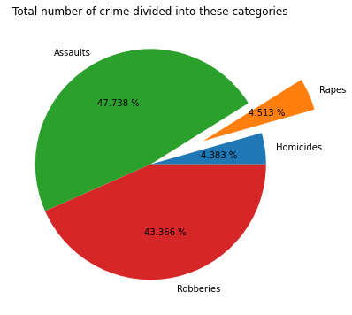

```python
total_homicides_crime = X2.homicides.sum()
total_rapes_crime = X2.rapes.sum()
total_assaults_crime = X2.assaults.sum()
total_robberies_crime = X2.robberies.sum()

plt.figure(figsize=(6,6))

label = ['Homicides','Rapes','Assaults','Robberies']
myexplode = [0, 0.5, 0, 0]
plt.pie([total_homicides_crime,total_rapes_crime,total_assaults_crime,total_robberies_crime], labels=label, autopct='%.3f %%',explode = myexplode)
plt.title('Total number of crime divided into these categories')

plt.show()
```

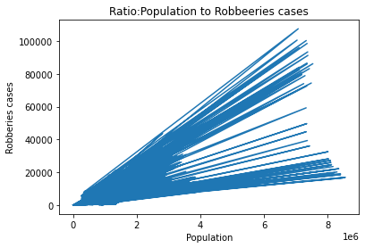

```python
plt.plot(X2['population'],X2['robberies'])
plt.xlabel('Population')
plt.ylabel('Robberies cases')
plt.title('Ratio:Population to Robbeeries cases')
plt.show()
```

# 7 Summary

In the summaries of the whole reports so we can easily summarize that the upawards steps more populations the more the crimes and so find crime data i crete first the do in the exploration and find table of the mean, median,max and the percentage of the whole data columns and than after i do the seclections of the columns of robbiers of 10 largest values and see that the newyorks city have more robbiers cases. After then i do the selection five type of the crimes columns make new data and show the data of the maneer way of the also crate the series. In the last step i do the plot of the pie chart and the ply.plot of the crimes tyoe we easliy visulizations of the crimes and shows that the robbiers and assulats crime are mores in americans cities are nearly the 45% is more than the the others crimes and do the ply.plot of the robbiers compare the polpulations so that more population then more risk of robbiers crimes.

# 8. Recommendations

As from the reference of the above study I can recommend to the FBI and commpanies who volunntering for this area regardind the crimes to protect the citizes, that they have to look at some the outcomes of the study and can make the decisions . The outcomes contains the city of crime ratios and the crime types is based of the past recoeds. Study shows that and pie chart easily shoe that the Assulats and the robberies contains the 47% and 43% of the total crimes of totle crimes complians. So, it can be easy for the FBI and other volunteering compies to select any type of the perticular crime data and crime and take the actions showing and making decisions.